# Red Maple Cultivar Work 2020

Michael Just

4/21/2020; 5/11/2020

# 1 Summary statistics

## 1.1 Gloomy scale densities

These are log10+1 per 15cm densities.  
A Wilcoxon signed rank test does not indicate a difference between 2018 and 2020 gloomy scale densities (v=1142, p=0.253)

| YEAR | TYPE | Imp_mean | Imp_sd | gloom_mean | gloom_sd | N | gloom.PostHoc | Imp.PostHoc | Good | Fair | Poor |
| --- | --- | --- | --- | --- | --- | --- | --- | --- | --- | --- | --- |
| 2018 | Wildtype | 21.83333 | 15.44307 | 0.0572520 | 0.1315568 | 30 | c | c | 20 | 7 | 3 |
| 2018 | Cultivar | 40.00000 | 24.95618 | 0.5754871 | 0.7555554 | 38 | b | b | 17 | 13 | 8 |
| 2018 | Hybrid | 60.12903 | 19.60908 | 1.0934806 | 0.6768414 | 31 | a | a | 4 | 21 | 6 |

| YEAR | TYPE | Imp_mean | Imp_sd | gloom_mean | gloom_sd | N | gloom.PostHoc | Imp.PostHoc | Good | Fair | Poor |
| --- | --- | --- | --- | --- | --- | --- | --- | --- | --- | --- | --- |
| 2020 | Wildtype | 20.69231 | 14.75878 | 0.1487237 | 0.3379625 | 26 | c | c | 19 | 4 | 3 |
| 2020 | Cultivar | 40.61765 | 25.31381 | 0.7292309 | 0.8486214 | 34 | b | b | 14 | 13 | 7 |
| 2020 | Hybrid | 60.03333 | 19.93694 | 1.1414979 | 0.8721388 | 30 | a | a | 4 | 20 | 6 |

## 1.2 Impervious surface and scale abundance

### 1.2.1 Counts from 2018

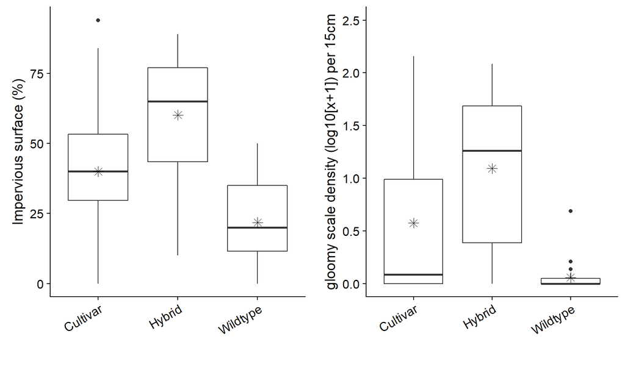

```r
imp_p <- ggplot(df19, aes(y=Imp, x = TYPE)) + geom_boxplot() +
  stat_summary(fun.y=mean, colour="black", geom="point", shape=8,
               size=3,show_guide = FALSE, position=position_dodge(width=0.75)) +
  ylab("Impervious surface (%)") + xlab("") +
  theme(axis.text.x = element_text(angle = 30, hjust=1, vjust=1))

scale_p <- ggplot(df19, aes(y=gloom, x = TYPE)) + geom_boxplot() +
  stat_summary(fun.y=mean, colour="black", geom="point", shape=8,
               size=3,show_guide = FALSE, position=position_dodge(width=0.75)) +
  ylab("gloomy scale density (log10[x+1]) per 15cm") + xlab("") + ylim(0,2.5) +
  theme(axis.text.x = element_text(angle = 30, hjust=1, vjust=1))
cowplot::plot_grid(imp_p, scale_p)
```

### 1.2.2 Counts from 2020

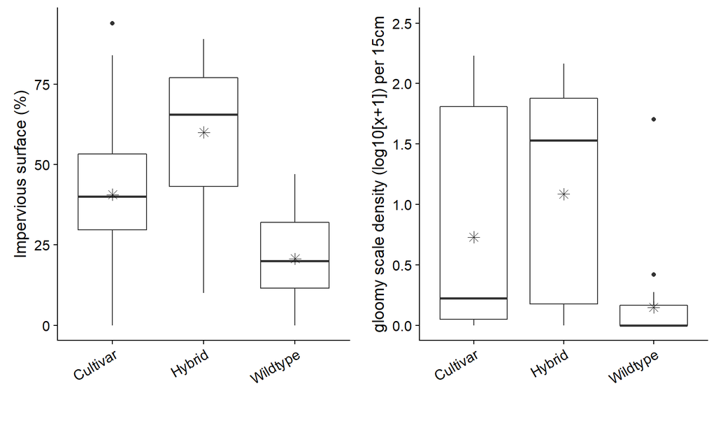

```r
imp_p <- ggplot(df20, aes(y=Imp, x = TYPE)) + geom_boxplot() +
  stat_summary(fun.y=mean, colour="black", geom="point", shape=8,
               size=3,show_guide = FALSE, position=position_dodge(width=0.75)) +
  ylab("Impervious surface (%)") + xlab("") +
  theme(axis.text.x = element_text(angle = 30, hjust=1, vjust=1))

scale_p <- ggplot(df20, aes(y=gloom, x = TYPE)) + geom_boxplot() +
  stat_summary(fun.y=mean, colour="black", geom="point", shape=8,
               size=3,show_guide = FALSE, position=position_dodge(width=0.75)) +
  ylab("gloomy scale density (log10[x+1]) per 15cm") + xlab("") + ylim(0,2.5) +
  theme(axis.text.x = element_text(angle = 30, hjust=1, vjust=1))
cowplot::plot_grid(imp_p, scale_p)
```

# 2 Scale ‘Diversity’

## 2.1 Scale Richness

Richness 2018 vs 2020 (per tree). * = mean

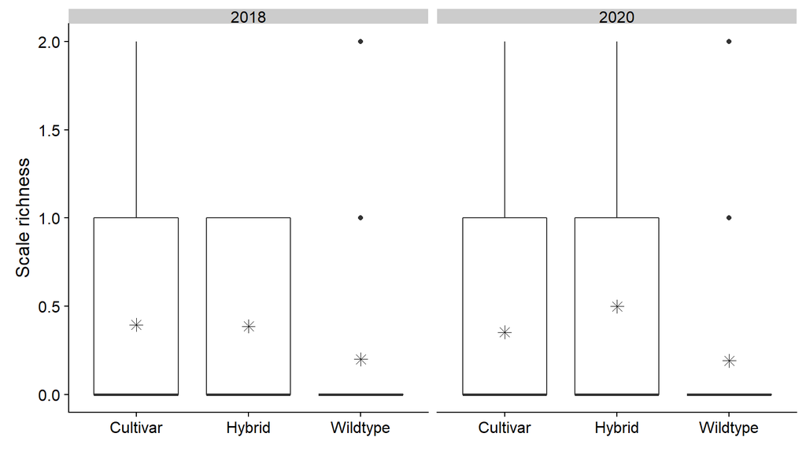

```r
df_r <- df %>% mutate(Richness = rowSums(.[,8:12]!=0))

ggplot(df_r, aes(y=Richness, x = TYPE)) + geom_boxplot() +
  stat_summary(fun.y=mean, colour="black", geom="point", shape=8,
               size=3,show_guide = FALSE, position=position_dodge(width=0.75)) +
  ylab("Scale richness") + xlab("") + facet_grid(~YEAR)
```

```r
  #theme(axis.text.x = element_text(angle = 30, hjust=1, vjust=1))  + theme_bw()
```

## 2.2 Scale loading proportions

Mean Propotions of each scale species per red maple type by year.  
B = obscure, G = gloomy, J = Japanese maple, L = lecanium/soft, O = oyster, X = unidentified

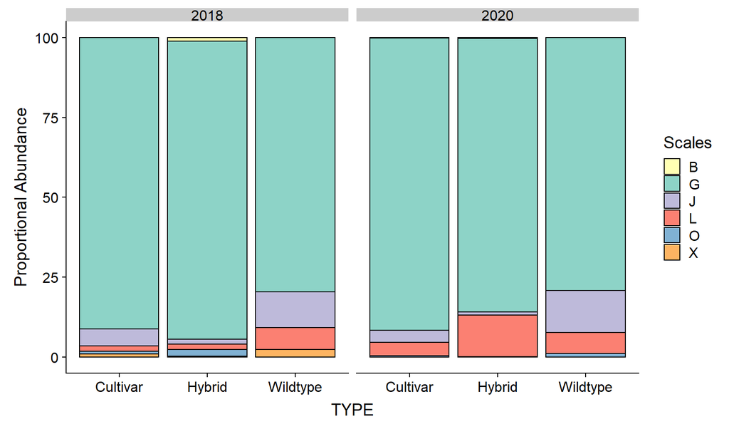

```r
dff1 <- df %>% group_by(YEAR, TYPE) %>%
  summarise_each(funs(mean), G15, B15, O15, J15, L15, X15) %>%
  ungroup %>%
  mutate(RS = rowSums(.[,3:8]))

# dff1.1 <- df %>% group_by(TYPE) %>%
#   summarise_each(funs(mean, sd, n()), Gdl, Odl, Jdl, Ldl, Xdl) %>%
#   #mutate(RS = rowSums(.[,2:7])) %>%
#   select(TYPE, Gloomy.mean = Gdl_mean, Gloomy.sd = Gdl_sd,
#          Oyster.mean = Odl_mean, Oyster.sd = Odl_sd,
#          JapaneseMaple.mean = Jdl_mean, JapaneseMaple.sd = Jdl_sd,
#          Lecanium.mean = Ldl_mean, Lecanium.sd = Ldl_sd,
#           X.mean = Xdl_mean, X.sd = Xdl_sd, N = Gdl_n)
#
# dff1.1 <- as.data.frame(dff1.1)

dff11 <- dff1 %>% group_by(YEAR, TYPE) %>%
  summarize(B = (B15/RS)*100, G = (G15/RS)*100, J = (J15/RS)*100, L = (L15/RS)*100, O = (O15/RS)*100, X = (X15/RS)*100)
target_cols <- names(dff11)[3:8]

dff1z <- dff11 %>% pivot_longer(cols=target_cols, names_to = "Scales", values_to = "Abundance")
# dfz19 <- dff1z %>% filter()

ggplot(dff1z, aes(x=TYPE, y = Abundance, fill = Scales)) +
  geom_bar(stat="identity", color="black") + ylab("Proportional Abundance") + facet_grid(~YEAR) + scale_fill_manual(values=c('#ffffb3','#8dd3c7','#bebada','#fb8072','#80b1d3','#fdb462')) + cowplot::theme_cowplot()
```

# 3 Gloomy Scales vs Impervious Surface Cover

Impervious surface is not a robust linear predictor of gloomy scale abundance

## 3.1 Results from 2018 data

### 3.1.1 All three red maple types

```r
fit.s.i <- lm(gloom~Imp, data=df19)
#kable(summary(fit.s.i)$coef, digits=2)
# stargazer(fit.s.i, type="html")
#
# lm(gloom~Imp, data=df19) %>%
#   tidy() %>%
#   mutate(
#     p.value = scales::pvalue(p.value),
#     term = c("Intercept", "% impervious")
#   ) %>%
#   kable(
#     caption = "Estimates for a model fitted to estimate gloomy scale density by impervious surface cover.",
#     col.names = c("Predictor", "Est.", "SE", "t", "p"),
#     digits = c(0, 2, 3, 2, 3),
#     align = c("l", "r", "r", "r", "r")
#   )


tab_model(fit.s.i, show.est=TRUE, show.se = TRUE, show.stat = TRUE, p.style = "a")
```

gloom

Predictors

Estimates

std. Error

CI

Statistic

(Intercept)

0.14

0.13

-0.12 – 0.39

1.09

Imp

0.01 ***

0.00

0.01 – 0.02

4.04

Observations

99

R<sup>2</sup> / R<sup>2</sup> adjusted

0.144 / 0.136

- p<0.05 ** p<0.01 *** p<0.001

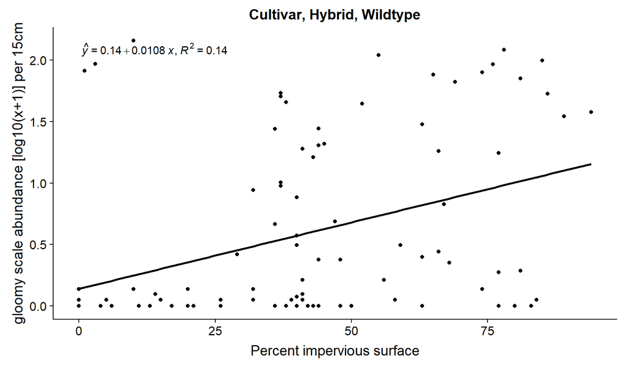

```r
my.formula <- y ~ x

ggplot(data = df19, aes(x = Imp, y = gloom)) +
  geom_smooth(method = "lm", se=FALSE, color="black", formula = my.formula) +
  stat_poly_eq(formula = my.formula,
               eq.with.lhs = "italic(hat(y))~`=`~",
               aes(label = paste(..eq.label.., ..rr.label.., sep = "*plain(\",\")~")),
               parse = TRUE) +
  geom_point() +
  ylab("gloomy scale abundance [log10(x+1)] per 15cm") + xlab("Percent impervious surface") +
  labs(title=paste(TYPE_Names,collapse=", "))
```

### 3.1.2 Each red maple type

```r
fit.s.i.c <- df19 %>% group_by(TYPE) %>% do(fit.c = lm(gloom~Imp,data=.))

tab_model(fit.s.i.c$fit.c, show.est=TRUE, show.se = TRUE, show.stat = TRUE, p.style = "a", dv.labels = TYPE_Names)
```

Cultivar

Hybrid

Wildtype

Predictors

Estimates

std. Error

CI

Statistic

Estimates

std. Error

CI

Statistic

Estimates

std. Error

CI

Statistic

(Intercept)

0.61 *

0.24

0.13 – 1.09

2.57

0.64

0.40

-0.17 – 1.45

1.62

0.00

0.04

-0.08 – 0.08

0.01

Imp

-0.00

0.01

-0.01 – 0.01

-0.17

0.01

0.01

-0.01 – 0.02

1.20

0.00

0.00

-0.00 – 0.01

1.70

Observations

38

31

30

R<sup>2</sup> / R<sup>2</sup> adjusted

0.001 / -0.027

0.047 / 0.015

0.093 / 0.061

- p<0.05 ** p<0.01 *** p<0.001

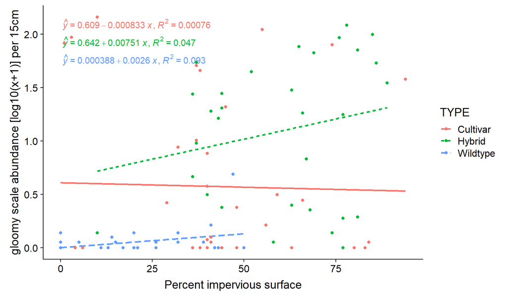

```r
my.formula <- y ~ x

ggplot(data = df19, aes(x = Imp, y = gloom, color=TYPE, lty=TYPE)) +
  geom_smooth(method = "lm", se=FALSE, formula = my.formula) +
  stat_poly_eq(formula = my.formula,
               eq.with.lhs = "italic(hat(y))~`=`~",
               aes(label = paste(..eq.label.., ..rr.label.., sep = "*plain(\",\")~")),
               parse = TRUE) +
  geom_point() +
  ylab("gloomy scale abundance [log10(x+1)] per 15cm") + xlab("Percent impervious surface")
```

## 3.2 Results from 2020 data

### 3.2.1 All three red maple types

```r
fit.s.i <- lm(gloom~Imp, data=df20)
tab_model(fit.s.i, show.est=TRUE, show.se = TRUE, show.stat = TRUE, p.style = "a")
```

gloom

Predictors

Estimates

std. Error

CI

Statistic

(Intercept)

0.24

0.16

-0.07 – 0.55

1.51

Imp

0.01 ***

0.00

0.00 – 0.02

3.44

Observations

90

R<sup>2</sup> / R<sup>2</sup> adjusted

0.119 / 0.108

- p<0.05 ** p<0.01 *** p<0.001

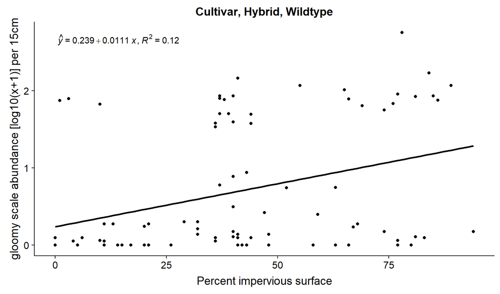

```r
my.formula <- y ~ x

ggplot(data = df20, aes(x = Imp, y = gloom)) +
  geom_smooth(method = "lm", se=FALSE, color="black", formula = my.formula) +
  stat_poly_eq(formula = my.formula,
               eq.with.lhs = "italic(hat(y))~`=`~",
               aes(label = paste(..eq.label.., ..rr.label.., sep = "*plain(\",\")~")),
               parse = TRUE) +
  geom_point() +
  ylab("gloomy scale abundance [log10(x+1)] per 15cm") + xlab("Percent impervious surface") +
  labs(title=paste(TYPE_Names,collapse=", "))
```

### 3.2.2 Each red maple type

```r
fit.s.i.c <- df20 %>% group_by(TYPE) %>% do(fit.c = lm(gloom~Imp,data=.))

tab_model(fit.s.i.c$fit.c, show.est=TRUE, show.se = TRUE, show.stat = TRUE, p.style = "a", dv.labels = TYPE_Names)
```

Cultivar

Hybrid

Wildtype

Predictors

Estimates

std. Error

CI

Statistic

Estimates

std. Error

CI

Statistic

Estimates

std. Error

CI

Statistic

(Intercept)

0.70 *

0.28

0.13 – 1.28

2.48

0.83

0.52

-0.23 – 1.89

1.61

-0.03

0.11

-0.26 – 0.19

-0.30

Imp

0.00

0.01

-0.01 – 0.01

0.12

0.01

0.01

-0.01 – 0.02

0.63

0.01

0.00

-0.00 – 0.02

2.03

Observations

34

30

26

R<sup>2</sup> / R<sup>2</sup> adjusted

0.000 / -0.031

0.014 / -0.021

0.146 / 0.111

- p<0.05 ** p<0.01 *** p<0.001

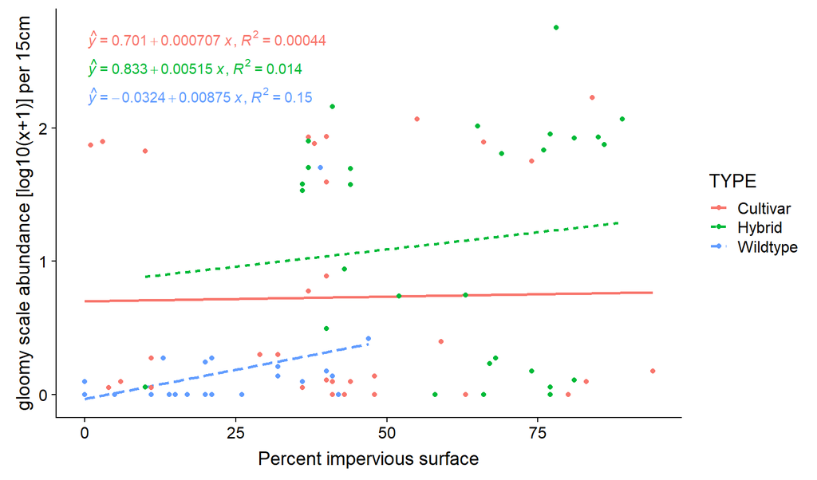

```r
my.formula <- y ~ x

ggplot(data = df20, aes(x = Imp, y = gloom, color=TYPE, lty=TYPE)) +
  geom_smooth(method = "lm", se=FALSE, formula = my.formula) +
  stat_poly_eq(formula = my.formula,
               eq.with.lhs = "italic(hat(y))~`=`~",
               aes(label = paste(..eq.label.., ..rr.label.., sep = "*plain(\",\")~")),
               parse = TRUE) +
  geom_point() +
  ylab("gloomy scale abundance [log10(x+1)] per 15cm") + xlab("Percent impervious surface")
```

## 3.3 Mean 2018 and 2020 results

### 3.3.1 All three red maple types

```r
fit.s.i <- lm(gloom~Imp, data=df1820)


tab_model(fit.s.i, show.est=TRUE, show.se = TRUE, show.stat = TRUE, p.style = "a")
```

gloom

Predictors

Estimates

std. Error

CI

Statistic

(Intercept)

0.17

0.13

-0.09 – 0.43

1.30

Imp

0.01 ***

0.00

0.01 – 0.02

4.07

Observations

99

R<sup>2</sup> / R<sup>2</sup> adjusted

0.146 / 0.137

- p<0.05 ** p<0.01 *** p<0.001

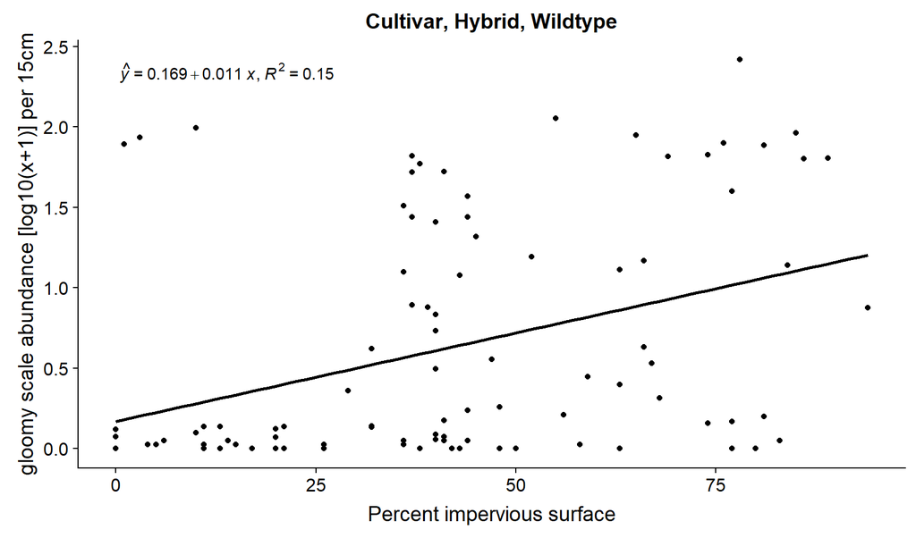

```r
my.formula <- y ~ x

ggplot(data = df1820, aes(x = Imp, y = gloom)) +
  geom_smooth(method = "lm", se=FALSE, color="black", formula = my.formula) +
  stat_poly_eq(formula = my.formula,
               eq.with.lhs = "italic(hat(y))~`=`~",
               aes(label = paste(..eq.label.., ..rr.label.., sep = "*plain(\",\")~")),
               parse = TRUE) +
  geom_point() +
  ylab("gloomy scale abundance [log10(x+1)] per 15cm") + xlab("Percent impervious surface") +
  labs(title=paste(TYPE_Names,collapse=", "))
```

### 3.3.2 Each red maple type

```r
fit.s.i.c <- df1820 %>% group_by(TYPE) %>% do(fit.c = lm(gloom~Imp,data=.))

tab_model(fit.s.i.c$fit.c, show.est=TRUE, show.se = TRUE, show.stat = TRUE, p.style = "a", dv.labels = TYPE_Names)
```

Cultivar

Hybrid

Wildtype

Predictors

Estimates

std. Error

CI

Statistic

Estimates

std. Error

CI

Statistic

Estimates

std. Error

CI

Statistic

(Intercept)

0.62 *

0.23

0.15 – 1.08

2.67

0.73

0.44

-0.16 – 1.62

1.68

-0.00

0.06

-0.12 – 0.11

-0.07

Imp

0.00

0.00

-0.01 – 0.01

0.09

0.01

0.01

-0.01 – 0.02

0.90

0.00 *

0.00

0.00 – 0.01

2.13

Observations

38

31

30

R<sup>2</sup> / R<sup>2</sup> adjusted

0.000 / -0.028

0.027 / -0.006

0.139 / 0.109

- p<0.05 ** p<0.01 *** p<0.001

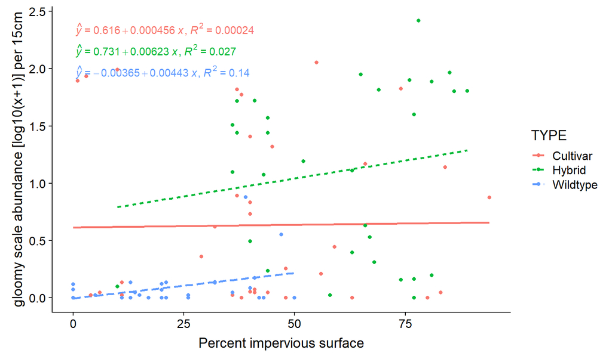

```r
my.formula <- y ~ x

ggplot(data = df1820, aes(x = Imp, y = gloom, color=TYPE, lty=TYPE)) +
  geom_smooth(method = "lm", se=FALSE, formula = my.formula) +
  stat_poly_eq(formula = my.formula,
               eq.with.lhs = "italic(hat(y))~`=`~",
               aes(label = paste(..eq.label.., ..rr.label.., sep = "*plain(\",\")~")),
               parse = TRUE) +
  geom_point() +
  ylab("gloomy scale abundance [log10(x+1)] per 15cm") + xlab("Percent impervious surface")
```

# 4 Tree Condition vs Impervious Surface

The relationship between impervious surface and tree condition is generally weak and largely not signficant with these datasets Combining all types provides more significance, maybe sample size are insufficient per type.  
Could try binary tree condition.

## 4.1 Results from 2018

### 4.1.1 All red maple types

```r
# row_spec(bb2, bold.me2, bold = TRUE, color = "brown", background="cyan")
bb7
```

| YEAR | TYPE | y.level | term | estimate | std.error | statistic | p.value | Chi2 | p.Chi2 |
| --- | --- | --- | --- | --- | --- | --- | --- | --- | --- |
| 2018 | Cultivar | Good | Imp | 0.957 | 0.01 | -3.86 | 0.000 | 22.38 | 0 |
| 2018 | Cultivar | Poor | Imp | 1.002 | 0.01 | 0.14 | 0.885 | 22.38 | 0 |

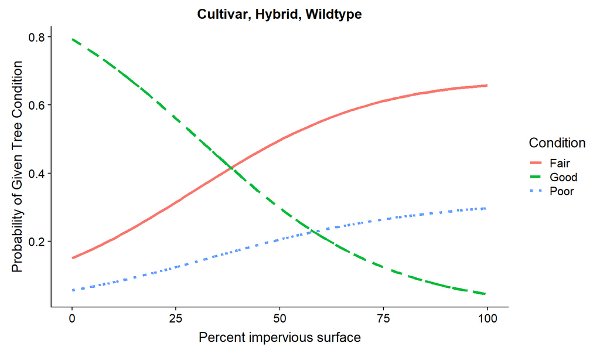

```r
ggplot(imp.preds.a19, aes(x = Imp, y = prob, color = Condition, lty=Condition)) + geom_line(size=1.25) +
  geom_line(size=1.15) + scale_linetype_manual(values = c("solid", "dashed", "dotted")) +
  ylab("Probability of Given Tree Condition") + xlab("Percent impervious surface") +
  labs(title=paste(TYPE_Names,collapse=", "))
```

### 4.1.2 Each red maple type

```r
# row_spec(bb2, bold.me2, bold = TRUE, color = "brown", background="cyan")
bb2
```

| YEAR | TYPE | y.level | term | estimate | std.error | statistic | p.value | Chi2 | p.Chi2 |
| --- | --- | --- | --- | --- | --- | --- | --- | --- | --- |
| **Cultivar** |  |  |  |  |  |  |  |  |  |
| 2018 | Cultivar | Good | Imp | 0.975 | 0.02 | -1.48 | 0.140 | 5.20 | 0.074 |
| 2018 | Cultivar | Poor | Imp | 1.016 | 0.02 | 0.82 | 0.412 | NA | NA |
| **Hybrid** |  |  |  |  |  |  |  |  |  |
| 2018 | Hybrid | Good | Imp | 0.987 | 0.03 | -0.45 | 0.651 | 0.44 | 0.804 |
| 2018 | Hybrid | Poor | Imp | 0.987 | 0.02 | -0.57 | 0.571 | NA | NA |
| **Wildtype** |  |  |  |  |  |  |  |  |  |
| 2018 | Wildtype | Good | Imp | 0.958 | 0.03 | -1.36 | 0.174 | 4.89 | 0.087 |
| 2018 | Wildtype | Poor | Imp | 1.049 | 0.06 | 0.86 | 0.391 | NA | NA |

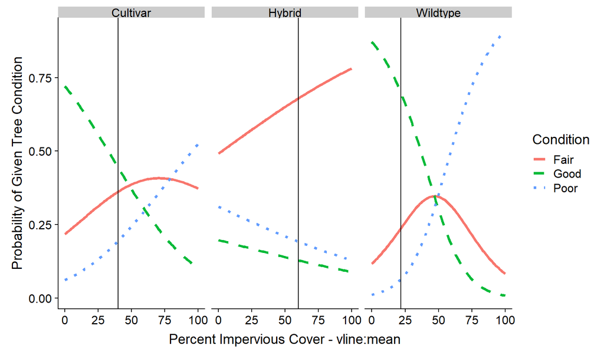

```r
ggplot(imp.preds19, aes(x = Imp, y = prob, color = Condition, lty=Condition)) + geom_line(size=1.25) +
  scale_linetype_manual(values = c("solid", "dashed", "dotted")) + #xlim(0.02,3.5) +
  ylab("Probability of Given Tree Condition") + xlab("Percent Impervious Cover - vline:mean") +
  facet_wrap( ~ TYPE) +
  geom_vline(aes(xintercept = MeanI))
```

## 4.2 Results from 2020

### 4.2.1 All red maple types

```r
# row_spec(bb2, bold.me2, bold = TRUE, color = "brown", background="cyan")
bb8
```

| YEAR | TYPE | y.level | term | estimate | std.error | statistic | p.value | Chi2 | p.Chi2 |
| --- | --- | --- | --- | --- | --- | --- | --- | --- | --- |
| 2020 | Cultivar | Good | Imp | 0.957 | 0.01 | -3.74 | 0.000 | 21.06 | 0 |
| 2020 | Cultivar | Poor | Imp | 1.001 | 0.01 | 0.06 | 0.949 | 21.06 | 0 |

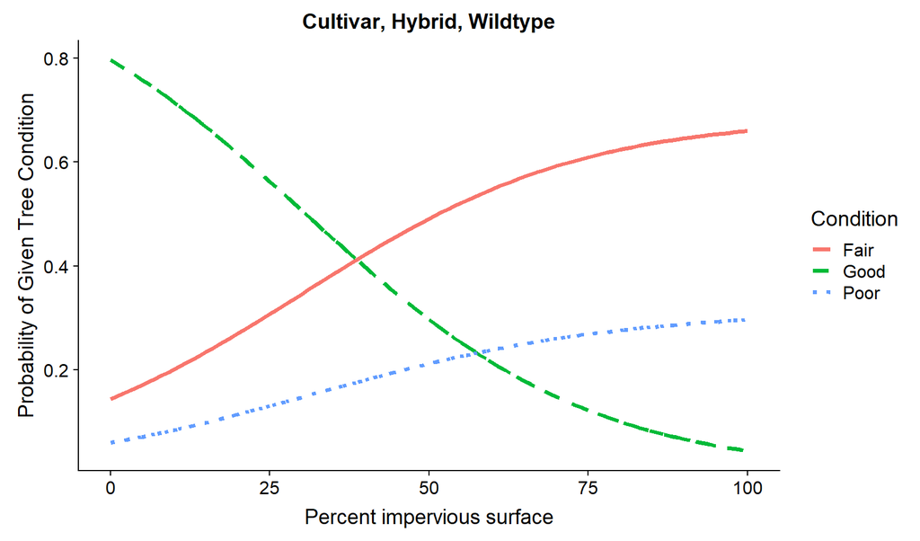

```r
ggplot(imp.preds.a20, aes(x = Imp, y = prob, color = Condition, lty=Condition)) + geom_line(size=1.25) +
  geom_line(size=1.15) + scale_linetype_manual(values = c("solid", "dashed", "dotted")) +
  ylab("Probability of Given Tree Condition") + xlab("Percent impervious surface") +
  labs(title=paste(TYPE_Names,collapse=", "))
```

### 4.2.2 Each red maple type

```r
# row_spec(bb2, bold.me2, bold = TRUE, color = "brown", background="cyan")
bb3
```

| YEAR | TYPE | y.level | term | estimate | std.error | statistic | p.value | Chi2 | p.Chi2 |
| --- | --- | --- | --- | --- | --- | --- | --- | --- | --- |
| **Cultivar** |  |  |  |  |  |  |  |  |  |
| 2020 | Cultivar | Good | Imp | 0.976 | 0.02 | -1.41 | 0.159 | 4.75 | 0.093 |
| 2020 | Cultivar | Poor | Imp | 1.018 | 0.02 | 0.87 | 0.387 | NA | NA |
| **Hybrid** |  |  |  |  |  |  |  |  |  |
| 2020 | Hybrid | Good | Imp | 0.988 | 0.03 | -0.44 | 0.662 | 0.41 | 0.816 |
| 2020 | Hybrid | Poor | Imp | 0.987 | 0.02 | -0.55 | 0.584 | NA | NA |
| **Wildtype** |  |  |  |  |  |  |  |  |  |
| 2020 | Wildtype | Good | Imp | 0.984 | 0.04 | -0.40 | 0.690 | 4.23 | 0.121 |
| 2020 | Wildtype | Poor | Imp | 1.096 | 0.07 | 1.30 | 0.195 | NA | NA |

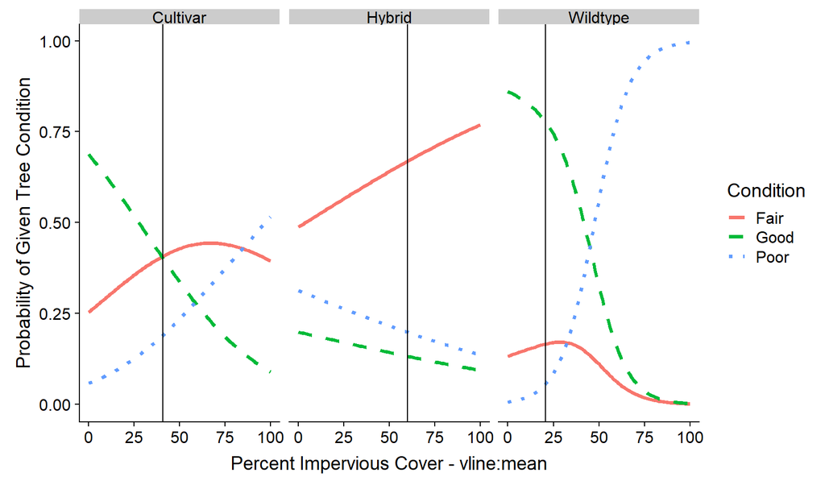

```r
ggplot(imp.preds20, aes(x = Imp, y = prob, color = Condition, lty=Condition)) + geom_line(size=1.25) +
  scale_linetype_manual(values = c("solid", "dashed", "dotted")) + #xlim(0.02,3.5) +
  ylab("Probability of Given Tree Condition") + xlab("Percent Impervious Cover - vline:mean") +
  facet_wrap( ~ TYPE) +
  geom_vline(aes(xintercept = MeanI))
```

## 4.3 Mean 2018 and 2020 results

### 4.3.1 All red maple types

```r
# row_spec(bb2, bold.me2, bold = TRUE, color = "brown", background="cyan")
bb7x
```

| y.level | term | estimate | std.error | statistic | p.value | Chi2 | p.Chi2 |
| --- | --- | --- | --- | --- | --- | --- | --- |
| Good | Imp | 0.957 | 0.01 | -3.86 | 0.000 | 22.38 | 0 |
| Poor | Imp | 1.002 | 0.01 | 0.14 | 0.885 | 22.38 | 0 |

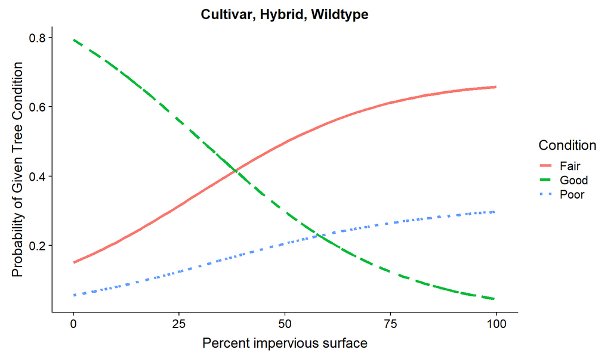

```r
ggplot(imp.preds2a, aes(x = Imp, y = prob, color = Condition, lty=Condition)) + geom_line(size=1.25) +
  geom_line(size=1.15) + scale_linetype_manual(values = c("solid", "dashed", "dotted")) +
  ylab("Probability of Given Tree Condition") + xlab("Percent impervious surface") +
  labs(title=paste(TYPE_Names,collapse=", "))
```

### 4.3.2 Each red maple type

```r
# row_spec(bb2, bold.me2, bold = TRUE, color = "brown", background="cyan")
bb2x
```

| TYPE | y.level | term | estimate | std.error | statistic | p.value | Chi2 | p.Chi2 |
| --- | --- | --- | --- | --- | --- | --- | --- | --- |
| **Cultivar** |  |  |  |  |  |  |  |  |
| Cultivar | Good | Imp | 0.975 | 0.02 | -1.48 | 0.140 | 5.20 | 0.074 |
| Cultivar | Poor | Imp | 1.016 | 0.02 | 0.82 | 0.412 | NA | NA |
| **Hybrid** |  |  |  |  |  |  |  |  |
| Hybrid | Good | Imp | 0.987 | 0.03 | -0.45 | 0.651 | 0.44 | 0.804 |
| Hybrid | Poor | Imp | 0.987 | 0.02 | -0.57 | 0.571 | NA | NA |
| **Wildtype** |  |  |  |  |  |  |  |  |
| Wildtype | Good | Imp | 0.958 | 0.03 | -1.36 | 0.174 | 4.89 | 0.087 |
| Wildtype | Poor | Imp | 1.049 | 0.06 | 0.86 | 0.391 | NA | NA |

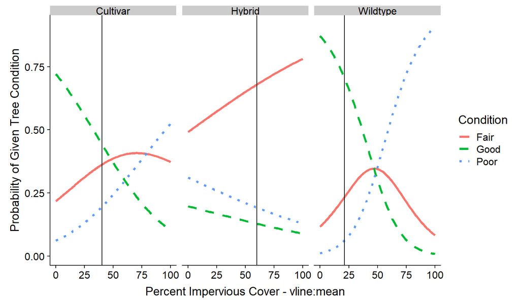

```r
ggplot(imp.preds, aes(x = Imp, y = prob, color = Condition, lty=Condition)) + geom_line(size=1.25) +
  scale_linetype_manual(values = c("solid", "dashed", "dotted")) + #xlim(0.02,3.5) +
  ylab("Probability of Given Tree Condition") + xlab("Percent Impervious Cover - vline:mean") +
  facet_wrap( ~ TYPE) +
  geom_vline(aes(xintercept = MeanI))
```

# 5 Gloomy Scale vs Tree Condition

## 5.1 Results from 2018

### 5.1.1 All red maple types

```r
# row_spec(bb2, bold.me2, bold = TRUE, color = "brown", background="cyan")
bb7
```

| YEAR | TYPE | y.level | term | estimate | std.error | statistic | p.value | Chi2 | p.Chi2 |
| --- | --- | --- | --- | --- | --- | --- | --- | --- | --- |
| 2018 | Cultivar | Good | gloom | 0.402 | 0.39 | -2.33 | 0.020 | 21.67 | 0 |
| 2018 | Cultivar | Poor | gloom | 2.884 | 0.40 | 2.65 | 0.008 | 21.67 | 0 |

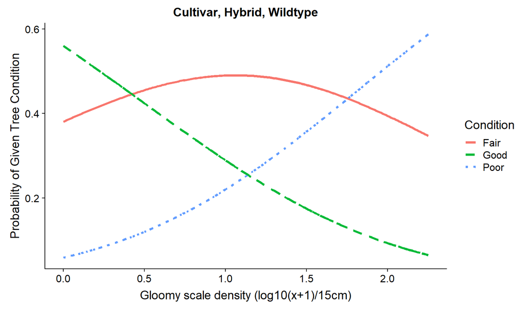

```r
ggplot(gloom.preds.a19, aes(x = gloom, y = prob, color = Condition, lty=Condition)) + geom_line(size=1.25) +
  geom_line(size=1.15) + scale_linetype_manual(values = c("solid", "dashed", "dotted")) +
  ylab("Probability of Given Tree Condition") + xlab("Gloomy scale density (log10(x+1)/15cm)") +
  labs(title=paste(TYPE_Names,collapse=", "))
```

### 5.1.2 Each red maple type

```r
# row_spec(bb2, bold.me2, bold = TRUE, color = "brown", background="cyan")
bb2
```

| YEAR | TYPE | y.level | term | estimate | std.error | statistic | p.value | Chi2 | p.Chi2 |
| --- | --- | --- | --- | --- | --- | --- | --- | --- | --- |
| **Cultivar** |  |  |  |  |  |  |  |  |  |
| 2018 | Cultivar | Good | gloom | 2.022000e+00 | 0.72 | 0.98 | 0.327 | 11.84 | 0.003 |
| 2018 | Cultivar | Poor | gloom | 9.441000e+00 | 0.82 | 2.73 | 0.006 | NA | NA |
| **Hybrid** |  |  |  |  |  |  |  |  |  |
| 2018 | Hybrid | Good | gloom | 3.880000e-01 | 0.91 | -1.04 | 0.300 | 4.97 | 0.083 |
| 2018 | Hybrid | Poor | gloom | 4.266000e+00 | 0.95 | 1.52 | 0.128 | NA | NA |
| **Wildtype** |  |  |  |  |  |  |  |  |  |
| 2018 | Wildtype | Good | gloom | 1.634896e+05 | 12.35 | 0.97 | 0.331 | 6.85 | 0.033 |
| 2018 | Wildtype | Poor | gloom | 1.348821e+09 | 13.82 | 1.52 | 0.128 | NA | NA |

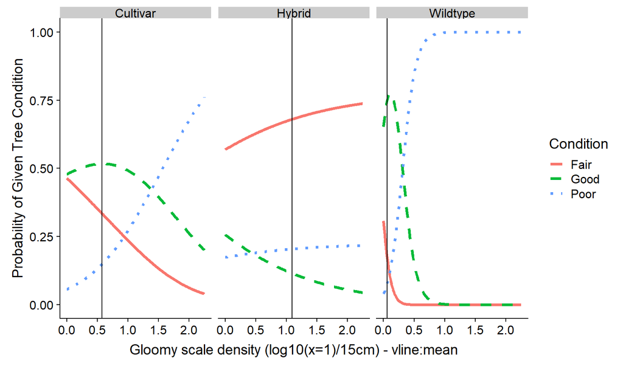

```r
ggplot(gloom.preds19, aes(x = gloom, y = prob, color = Condition, lty=Condition)) + geom_line(size=1.25) +
  scale_linetype_manual(values = c("solid", "dashed", "dotted")) + #xlim(0.02,3.5) +
  ylab("Probability of Given Tree Condition") + xlab("Gloomy scale density (log10(x=1)/15cm) - vline:mean") +
  facet_wrap( ~ TYPE) +
  geom_vline(aes(xintercept = MeanG))
```

## 5.2 Results from 2020

### 5.2.1 All red maple types

```r
# row_spec(bb2, bold.me2, bold = TRUE, color = "brown", background="cyan")
bb8
```

| YEAR | TYPE | y.level | term | estimate | std.error | statistic | p.value | Chi2 | p.Chi2 |
| --- | --- | --- | --- | --- | --- | --- | --- | --- | --- |
| 2020 | Cultivar | Good | gloom | 0.567 | 0.31 | -1.83 | 0.067 | 7.49 | 0.024 |
| 2020 | Cultivar | Poor | gloom | 1.463 | 0.34 | 1.12 | 0.263 | 7.49 | 0.024 |

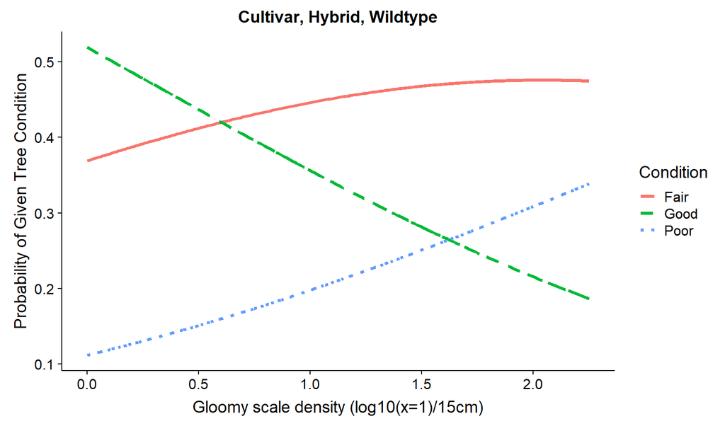

```r
ggplot(gloom.preds.a20, aes(x = gloom, y = prob, color = Condition, lty=Condition)) + geom_line(size=1.25) +
  geom_line(size=1.15) + scale_linetype_manual(values = c("solid", "dashed", "dotted")) +
  ylab("Probability of Given Tree Condition") + xlab("Gloomy scale density (log10(x=1)/15cm)") +
  labs(title=paste(TYPE_Names,collapse=", "))
```

### 5.2.2 Each red maple type

```r
# row_spec(bb2, bold.me2, bold = TRUE, color = "brown", background="cyan")
bb3
```

| YEAR | TYPE | y.level | term | estimate | std.error | statistic | p.value | Chi2 | p.Chi2 |
| --- | --- | --- | --- | --- | --- | --- | --- | --- | --- |
| **Cultivar** |  |  |  |  |  |  |  |  |  |
| 2020 | Cultivar | Good | gloom | 4.148 | 0.72 | 1.96 | 0.050 | 10.30 | 0.006 |
| 2020 | Cultivar | Poor | gloom | 7.911 | 0.81 | 2.54 | 0.011 | NA | NA |
| **Hybrid** |  |  |  |  |  |  |  |  |  |
| 2020 | Hybrid | Good | gloom | 0.408 | 0.73 | -1.23 | 0.219 | 1.79 | 0.409 |
| 2020 | Hybrid | Poor | gloom | 0.984 | 0.55 | -0.03 | 0.976 | NA | NA |
| **Wildtype** |  |  |  |  |  |  |  |  |  |
| 2020 | Wildtype | Good | gloom | 0.061 | 2.34 | -1.19 | 0.233 | 2.91 | 0.233 |
| 2020 | Wildtype | Poor | gloom | 0.427 | 1.67 | -0.51 | 0.610 | NA | NA |

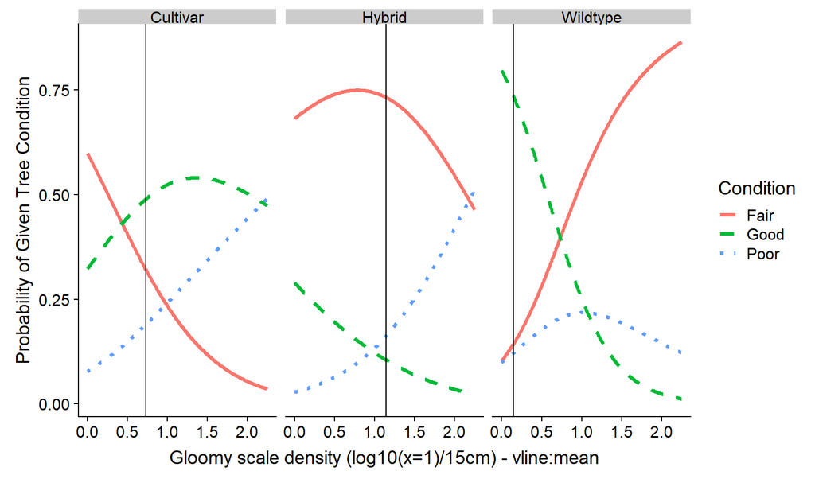

```r
ggplot(gloom.preds20, aes(x = gloom, y = prob, color = Condition, lty=Condition)) + geom_line(size=1.25) +
  scale_linetype_manual(values = c("solid", "dashed", "dotted")) + #xlim(0.02,3.5) +
  ylab("Probability of Given Tree Condition") + xlab("Gloomy scale density (log10(x=1)/15cm) - vline:mean") +
  facet_wrap( ~ TYPE) +
  geom_vline(aes(xintercept = MeanG))
```

## 5.3 Mean 2018 and 2020 results

### 5.3.1 All red maple types

```r
# row_spec(bb2, bold.me2, bold = TRUE, color = "brown", background="cyan")
bb7xg
```

| y.level | term | estimate | std.error | statistic | p.value | Chi2 | p.Chi2 |
| --- | --- | --- | --- | --- | --- | --- | --- |
| Good | gloom | 0.456 | 0.36 | -2.17 | 0.030 | 15.85 | 0 |
| Poor | gloom | 2.282 | 0.38 | 2.16 | 0.031 | 15.85 | 0 |

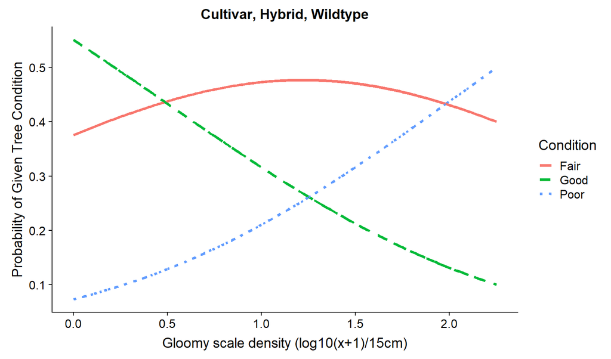

```r
ggplot(gloom.preds2a, aes(x = gloom, y = prob, color = Condition, lty=Condition)) + geom_line(size=1.25) +
  geom_line(size=1.15) + scale_linetype_manual(values = c("solid", "dashed", "dotted")) +
  ylab("Probability of Given Tree Condition") + xlab("Gloomy scale density (log10(x+1)/15cm)") +
  labs(title=paste(TYPE_Names,collapse=", "))
```

### 5.3.2 Each red maple type

```r
# row_spec(bb2, bold.me2, bold = TRUE, color = "brown", background="cyan")
bb2xg
```

| TYPE | y.level | term | estimate | std.error | statistic | p.value | Chi2 | p.Chi2 |
| --- | --- | --- | --- | --- | --- | --- | --- | --- |
| **Cultivar** |  |  |  |  |  |  |  |  |
| Cultivar | Good | gloom | 3.339 | 0.78 | 1.54 | 0.124 | 12.71 | 0.002 |
| Cultivar | Poor | gloom | 13.927 | 0.93 | 2.84 | 0.005 | NA | NA |
| **Hybrid** |  |  |  |  |  |  |  |  |
| Hybrid | Good | gloom | 0.375 | 0.85 | -1.15 | 0.248 | 2.59 | 0.274 |
| Hybrid | Poor | gloom | 1.720 | 0.70 | 0.78 | 0.436 | NA | NA |
| **Wildtype** |  |  |  |  |  |  |  |  |
| Wildtype | Good | gloom | 0.066 | 2.84 | -0.96 | 0.338 | 2.41 | 0.299 |
| Wildtype | Poor | gloom | 4.323 | 2.50 | 0.59 | 0.559 | NA | NA |

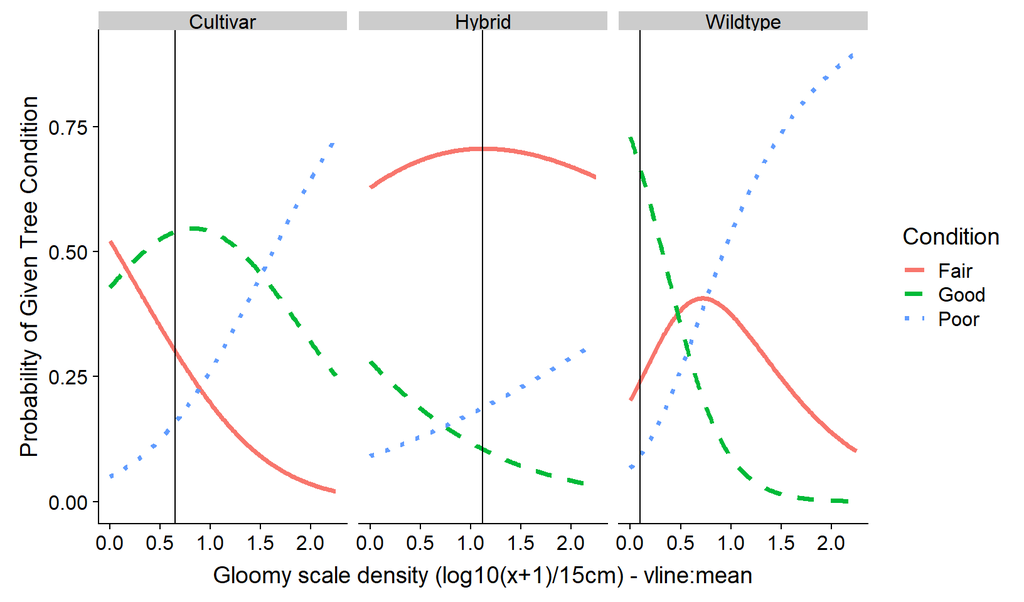

```r
ggplot(gloom.preds, aes(x = gloom, y = prob, color = Condition, lty=Condition)) + geom_line(size=1.25) +
  scale_linetype_manual(values = c("solid", "dashed", "dotted")) +
  ylab("Probability of Given Tree Condition") + xlab("Gloomy scale density (log10(x+1)/15cm) - vline:mean") +
  facet_wrap( ~ TYPE) +
  geom_vline(aes(xintercept = MeanG))
```